# Exploratory Data Analysis

## Schooling

Definition: Average number of completed years of education of a country’s population aged 25 years and older, excluding years spent repeating individual grades.

Missing values: 10 countries are missing all the values Data accuracy: most of it seems accurate but there are some issues, for example Turkmenistan where is’s 0 for 2000 and 2001 and 10.2 for 2002

This maybe redundant with Income composition of resources (HDI).

```r
investigate_missing_column_values("Schooling")
```

```
## [1] 130
## # A tibble: 13 x 2
##    Year.factor missing
##    <fct>         <int>
##  1 2000             10
##  2 2001             10
##  3 2002             10
##  4 2003             10
##  5 2004             10
##  6 2005             10
##  7 2006             10
##  8 2007             10
##  9 2008             10
## 10 2009             10
## 11 2010             10
## 12 2011             10
## 13 2012             10
## # A tibble: 10 x 2
##    Country.factor                                       missing
##    <fct>                                                  <int>
##  1 Côte d'Ivoire                                             13
##  2 Czechia                                                   13
##  3 Democratic People's Republic of Korea                     13
##  4 Democratic Republic of the Congo                          13
##  5 Republic of Korea                                         13
##  6 Republic of Moldova                                       13
##  7 Somalia                                                   13
##  8 United Kingdom of Great Britain and Northern Ireland      13
##  9 United Republic of Tanzania                               13
## 10 United States of America                                  13
```

# Finalized Missing Data

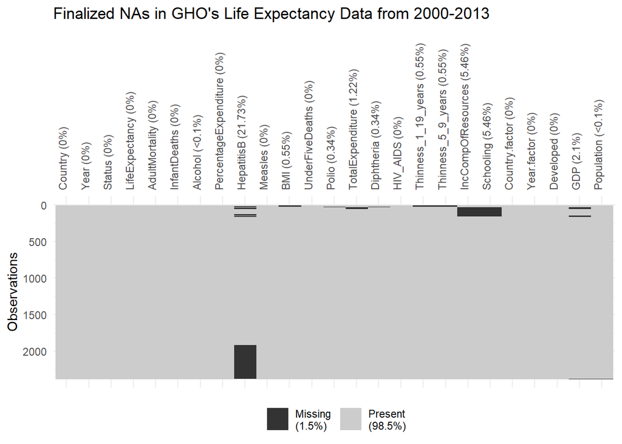

```r
vis_miss(life_expectancy, cluster = T) + # With aggregating observations
  labs(title = "Finalized NAs in GHO's Life Expectancy Data from 2000-2013") +
  theme(axis.text.x = element_text(angle=90))
```

## Scatterplots before data cleaning

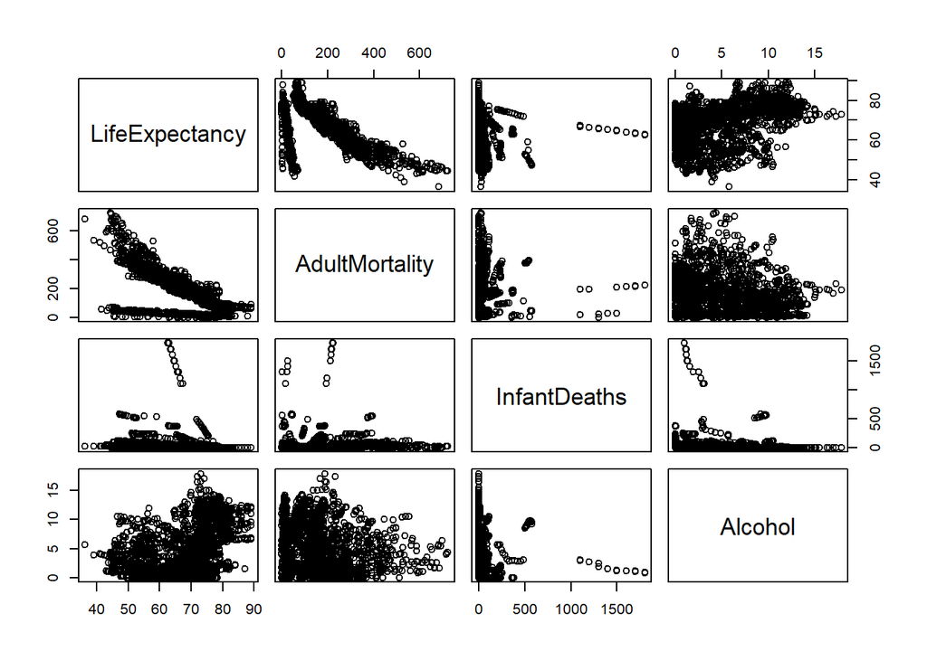

```r
pairs(life_expectancy[,c(4:7)])
```

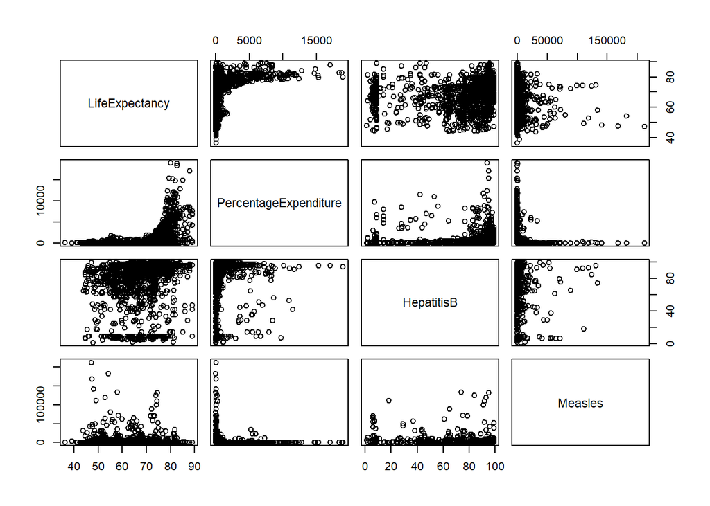

```r
pairs(life_expectancy[,c(4,8:10)])
```

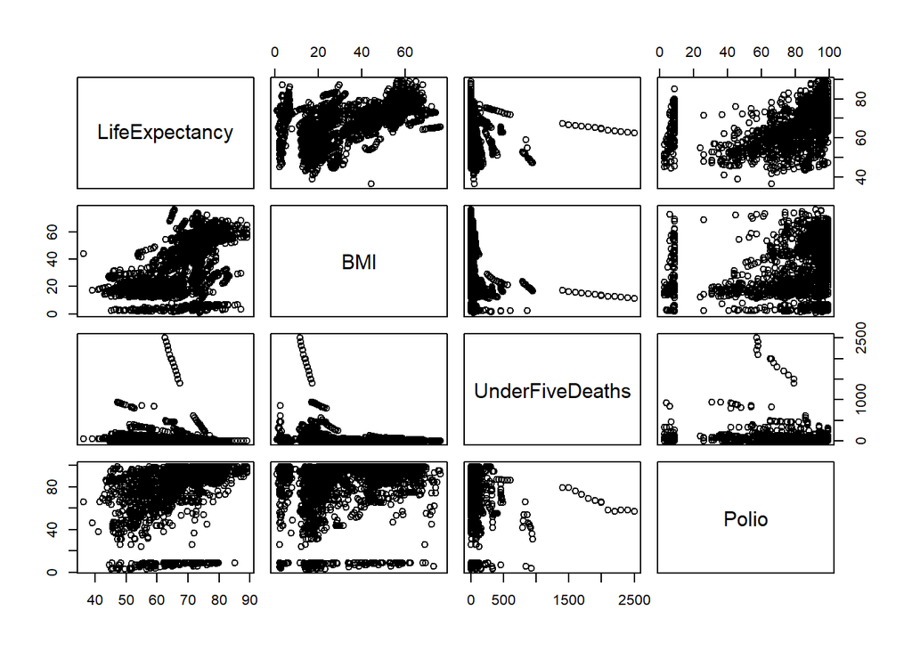

```r
pairs(life_expectancy[,c(4,11:13)])
```

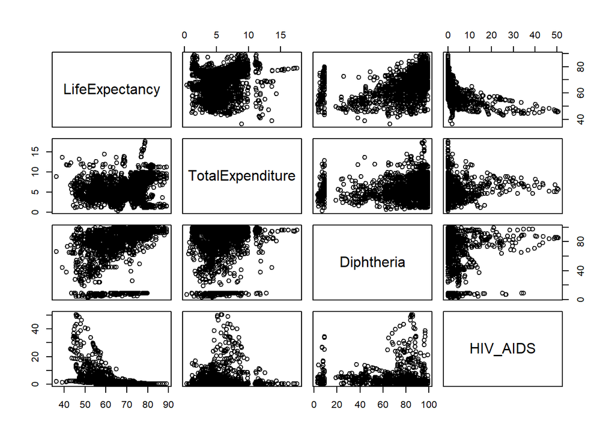

```r
pairs(life_expectancy[,c(4,14:16)])
```

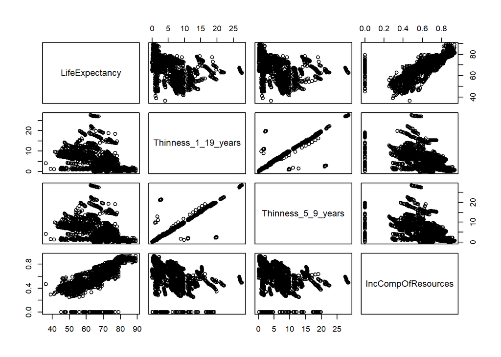

```r
pairs(life_expectancy[,c(4,17:19)])
```

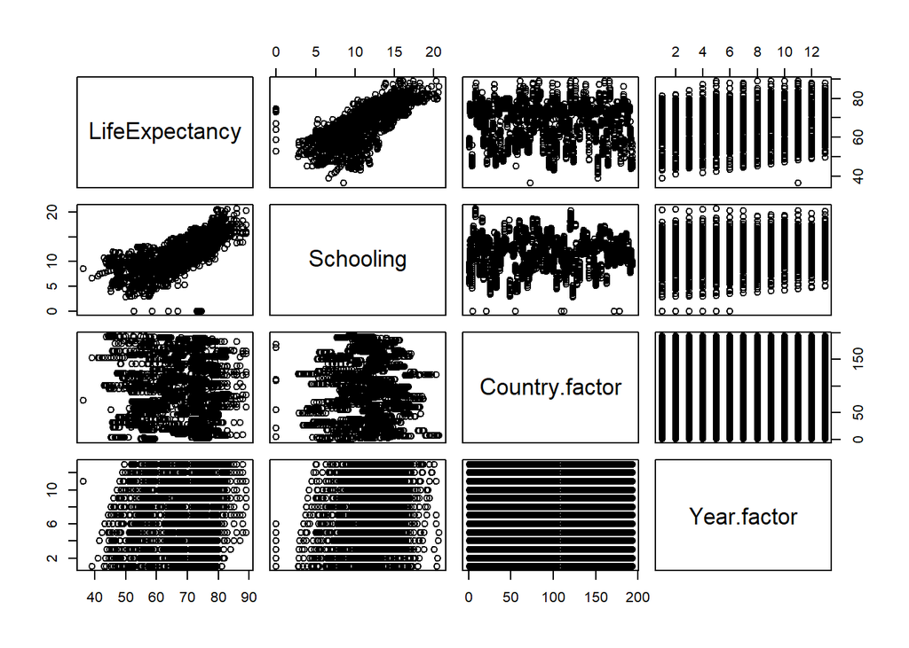

```r
pairs(life_expectancy[,c(4,20:22)])
```

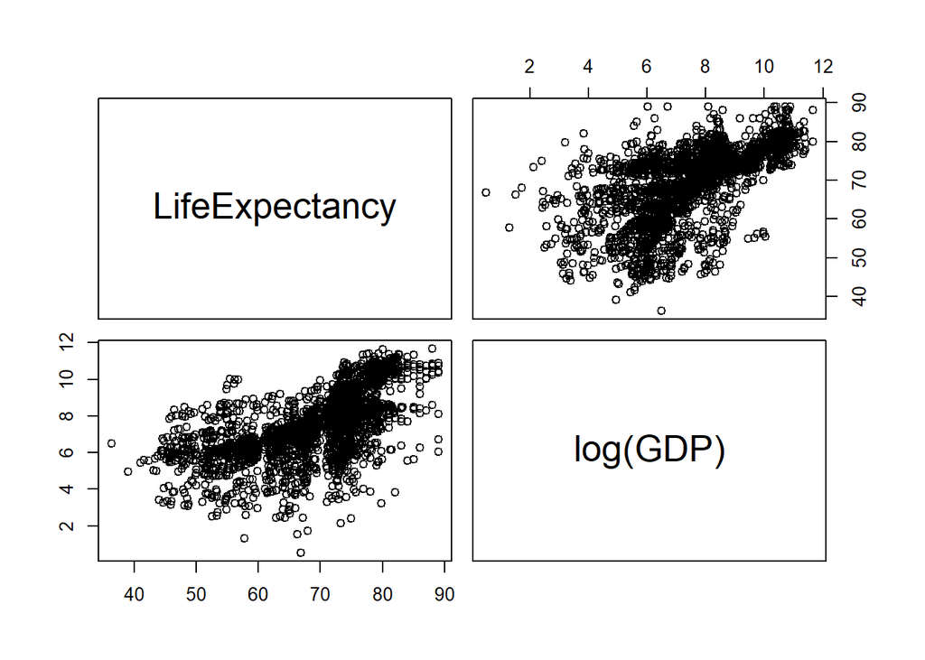

```r
life_expectancy <- mutate(life_expectancy, log(GDP))

# Potential spread issue
pairs(life_expectancy[,c("LifeExpectancy","log(GDP)")])
```

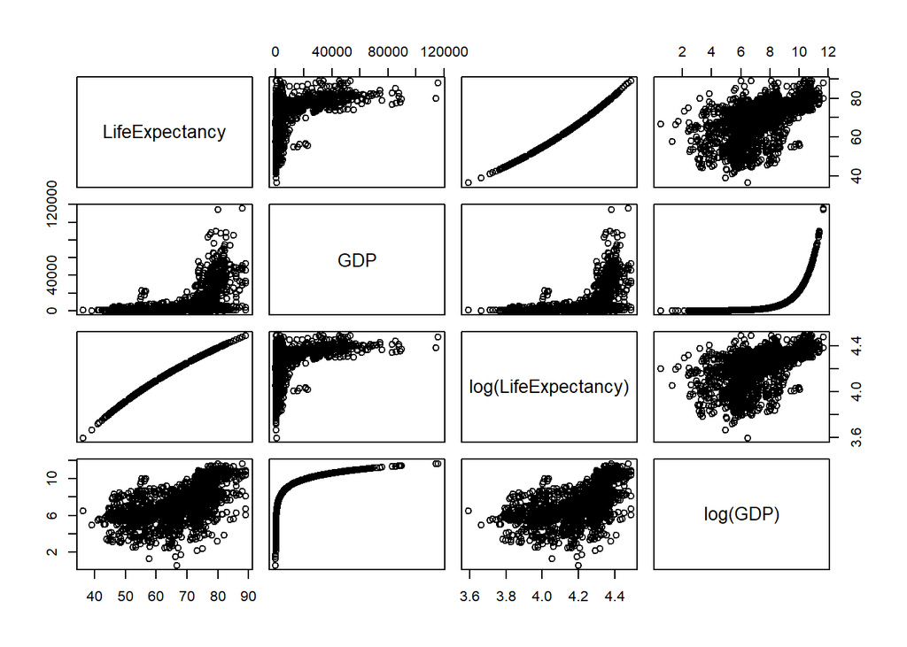

```r
# Log transformation
life_expectancy <- mutate(life_expectancy, log(LifeExpectancy))

# Transforming life expectancy by log does not appear to help too much, will use LifeExpectancy over log(LifeExpectancy) for models
pairs(life_expectancy[,c("LifeExpectancy", "GDP", "log(LifeExpectancy)","log(GDP)")])
```

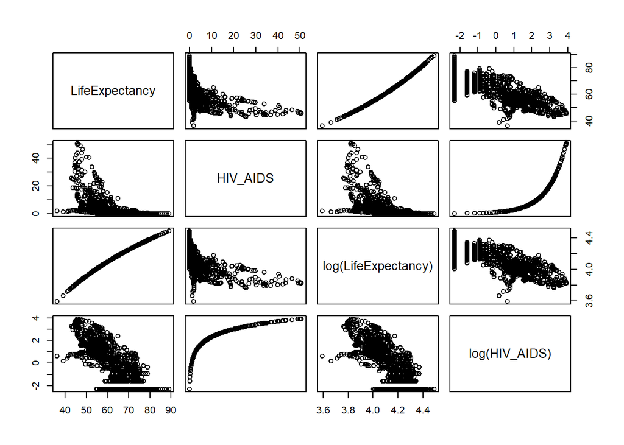

```r
# HIV_AIDS
life_expectancy <- mutate(life_expectancy, log(HIV_AIDS))
pairs(life_expectancy[,c("LifeExpectancy", "HIV_AIDS", "log(LifeExpectancy)","log(HIV_AIDS)")])
```

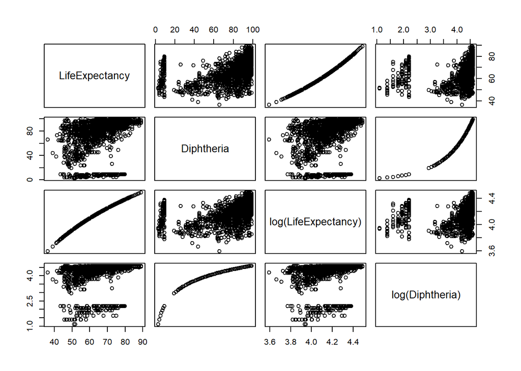

```r
# Diphtheria
life_expectancy <- mutate(life_expectancy, log(Diphtheria))
pairs(life_expectancy[,c("LifeExpectancy", "Diphtheria", "log(LifeExpectancy)","log(Diphtheria)")])
```

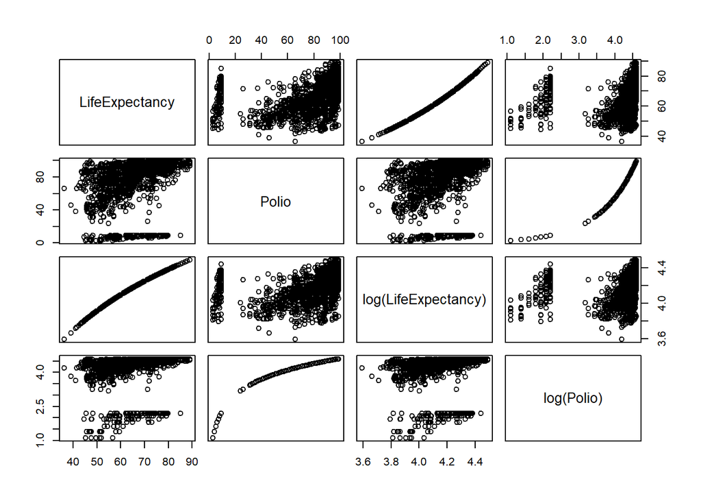

```r
# Missing data creates an interesting scatterplot range/spread


# Polio
life_expectancy <- mutate(life_expectancy, log(Polio))
pairs(life_expectancy[,c("LifeExpectancy", "Polio", "log(LifeExpectancy)","log(Polio)")])
```

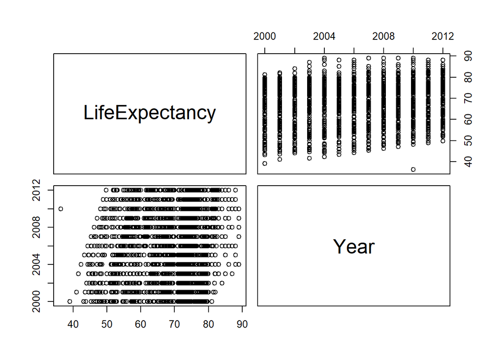

```r
# Log transforming Polio does not look to be helping and is creating divergent trends, potential issue for missing data or representation from 10-35%?

pairs(life_expectancy[,c("LifeExpectancy", "Year")])
```

```r
# Does not appear to have a spread problem but potential slight positive trend
```

# Scatterplots with data separation: Developed/Developing by Status

Checking to see how relationships differ when the data is separating countries by their status of developed or developing.

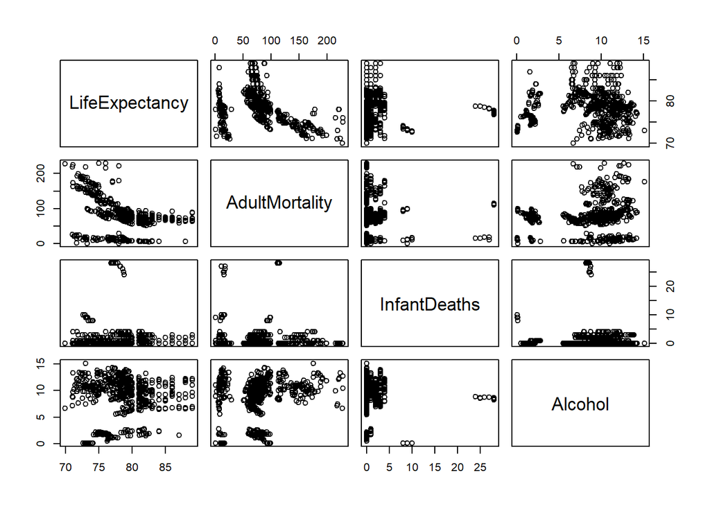

```r
le_developed <- life_expectancy %>% filter(Status == "Developed")
le_developing <- life_expectancy %>% filter(Status == "Developing")

pairs(le_developed[,c(4:7)])
```

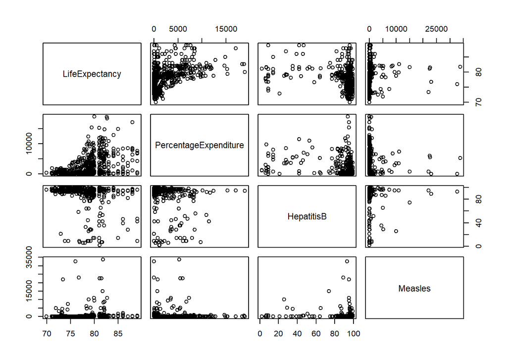

```r
pairs(le_developed[,c(4,8:10)])
```

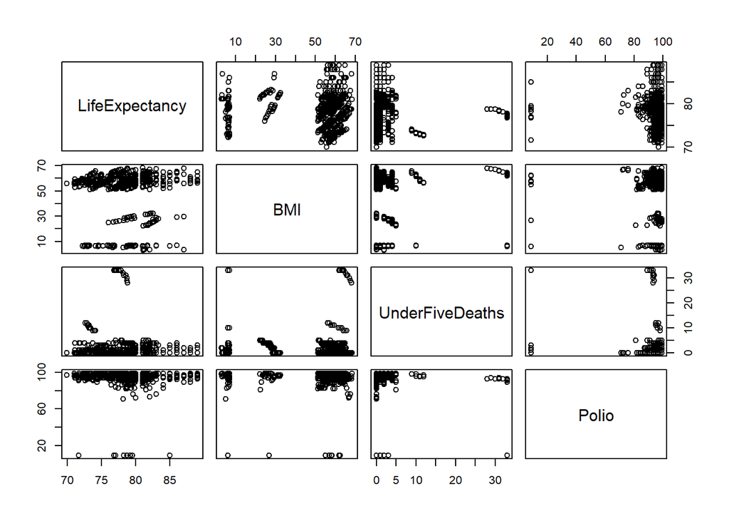

```r
pairs(le_developed[,c(4,11:13)])
```

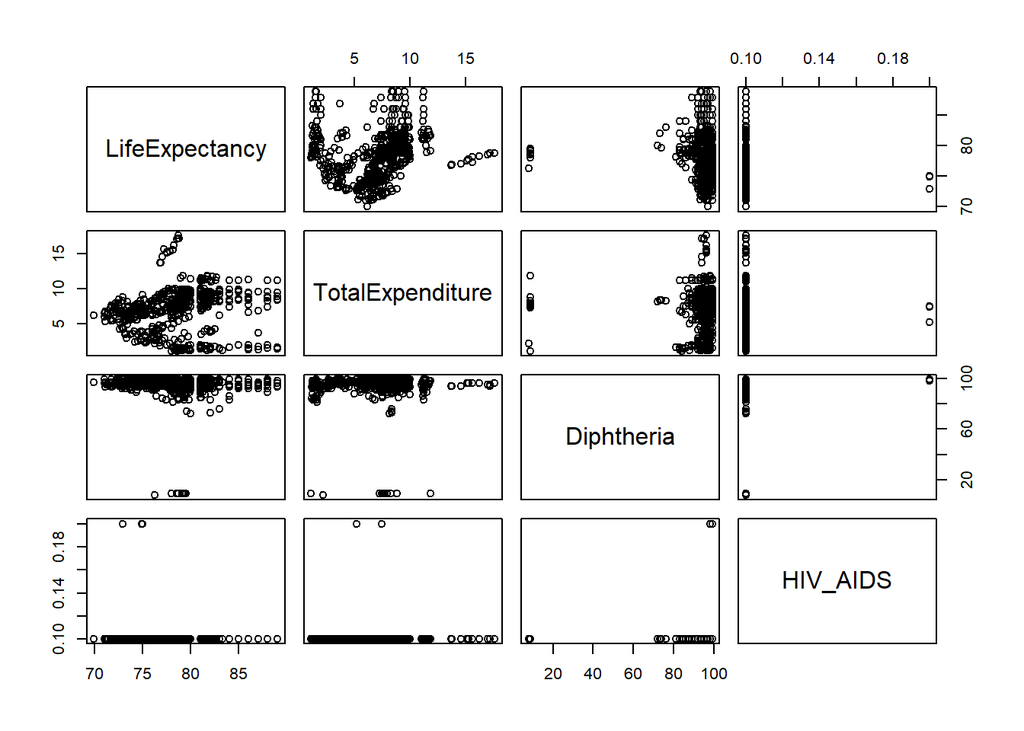

```r
pairs(le_developed[,c(4,14:16)])
```

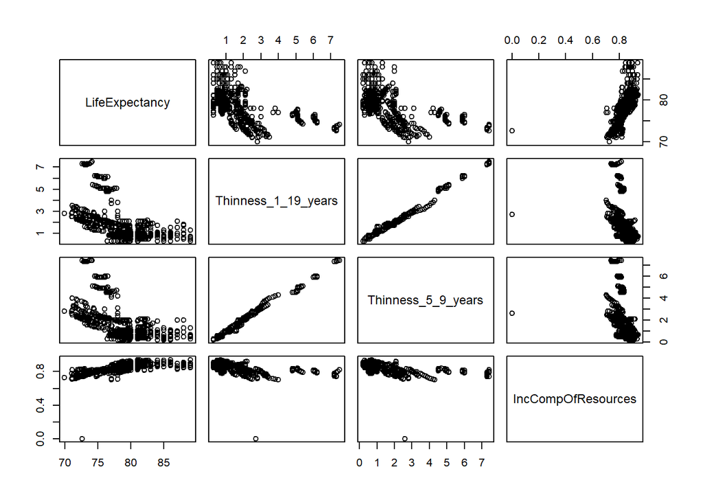

```r
pairs(le_developed[,c(4,17:19)])
```

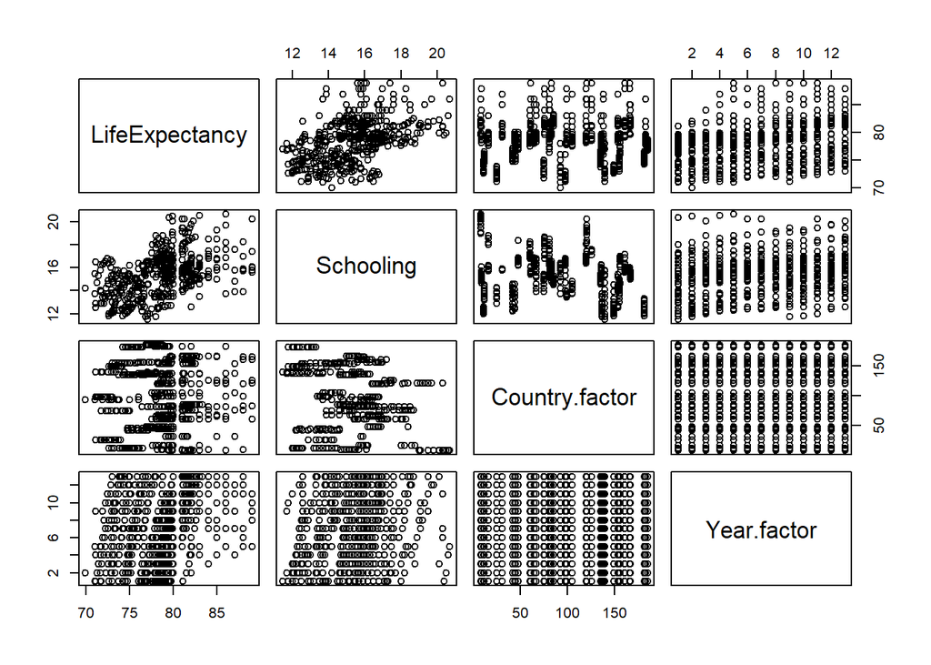

```r
pairs(le_developed[,c(4,20:22)])
```

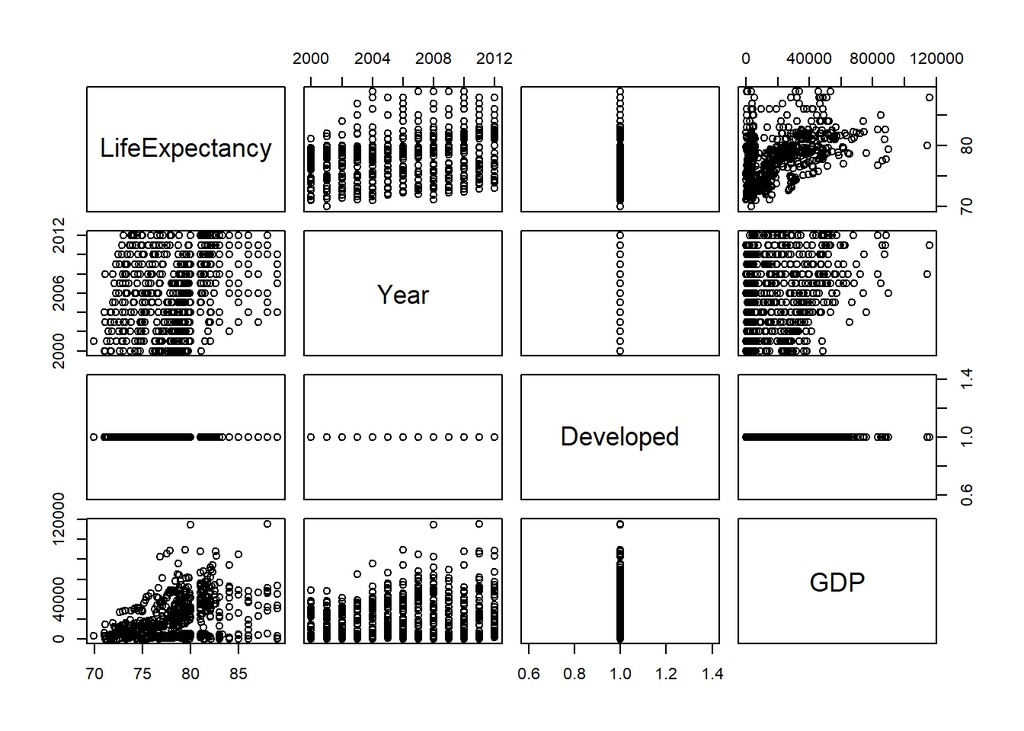

```r
pairs(le_developed[,c(4,2,23,24)])
```